# Quality of Activity Classification

Michael Szczepaniak

December 2015

## Background

People that are into tracking their personal data with a Jawbone Up, Nike FuelBand, Fitbit or whatever activity tracker they use regularly quantify how much of a particular activity they do. However, they rarely quantify the quality of how they conduct these activities. In this project, the goal was to use data from accelerometers on the belt, forearm, arm, and dumbell of 6 participants. They were asked to perform barbell lifts correctly and incorrectly in 5 different ways. More information is available from the website here: http://groupware.les.inf.puc-rio.br/har (see the section on the Weight Lifting Exercise Dataset).

## Synposis

A Random Forrest (RF) model with 31 predictors was selected for use to predict 20 final validation test cases. While the RF model accurately predicted all 20 test cases, a Boosted Tree model (GBM) was able to predict 90% of the validation cases correctly. Two other model types were evaluated as part of the investigation: Linear Discriminant Analysis (LDA) and Recursive Partitioning and Regression Tree (RPART). The LDA and RPART models were eliminated due to high in-sample error rates (44.5% and 56.3% respectively). The RF model had a better in-sample error rate compared to GBM (0% vs. 6% for GBM), but the RF model took over 178 minutes to train using default caret setting while the GBM only took about 10 minutes using 5 repeats of 5-fold cross-validation. The out-of-sample error rates estimated from the testing hold-outs for the GBM and RF models were 8% and 1.6% respectively.

The code behind all the calculations can be found in [this RMarkdown file](https://github.com/MichaelSzczepaniak/QualityOfActivityClassifier/raw/master/qualityOfActivity.Rmd).

## Variable Selection

The training data was downloaded from [here](https://github.com/MichaelSzczepaniak/QualityOfActivityClassifier/raw/master/pml-training.csv) and the testing data [here](https://github.com/MichaelSzczepaniak/QualityOfActivityClassifier/raw/master/pml-testing.csv). Both of these datasets were obtained from the groupware site referred to above. After downloading the data files, the training data was read and the columns with missing data were removed. Eliminating the missing and sparsely populated column took the variable count from 159 down to 59. The next reduction came from identifying and removing highly correlated variables which took the count from 59 down to 37. The last reduction came from the elimination of variables that should not be used as predictors such as timestamp related information which are not intrisic to the user or the activity. This final reduction brought the count down to 31.

Details regarding the variable reduction process are described in [Appendix A](http://michaelszczepaniak.github.io/QualityOfActivityClassifier/Appendices.html) and are summarized in **Figure 1** below.

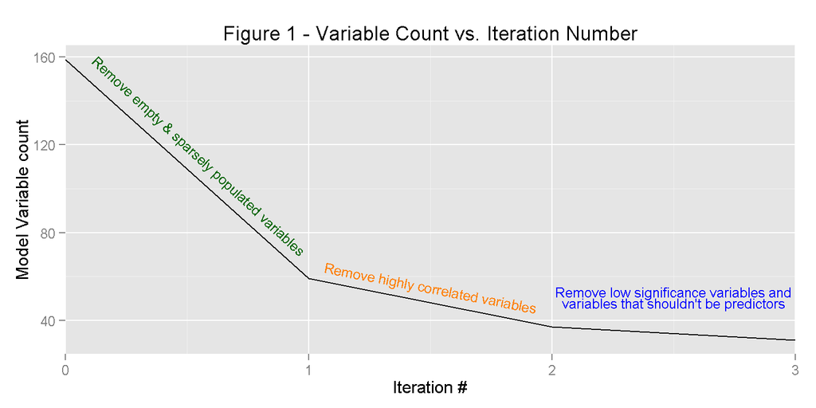

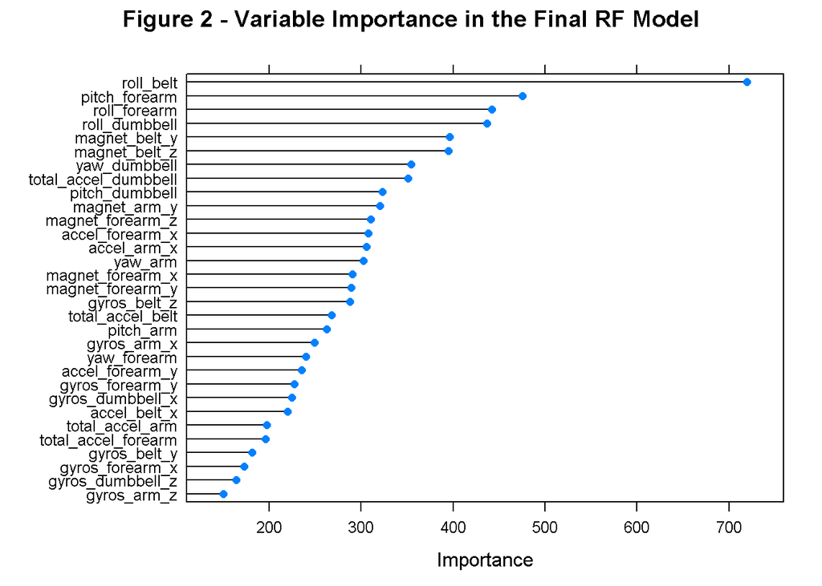

```r
importance <- varImp(mod03.rf, scale=FALSE)
plot(importance, main="Figure 2 - Variable Importance in the Final RF Model")
```

## Data Partitioning and Model Builds

After the predictors were selected, the data was partitioned such that 60% of the data was allocated to the training set and 40% to the test set using the code shown below.

```r
set.seed(1447)
inTrain <- createDataPartition(trimmedActivity3$classe, p=0.60, list=FALSE)
training <- trimmedActivity3[inTrain,]
testing <- trimmedActivity3[-inTrain,]
```

Each model was built by passing the **training** set to the *train* function in *caret* package as shown below. For details see [Appendix B](http://michaelszczepaniak.github.io/QualityOfActivityClassifier/Appendices.html#appendix-b---calculation-of-error-and-accuracy).

```r
set.seed(374659)
mod01.lda <- train(classe ~ ., method='lda', data=training)    # LDA model build
# ...
set.seed(1449)
mod02.cart <- train(classe ~ ., method='rpart', data=training) # RPART model build
# ...
# Random Forrest model build
set.seed(1451); mod03.rf <- train(classe ~ ., method='rf', prox=TRUE, data=training)
# ...
# GBM (boosted tree) model build
ctrl <- trainControl(method = "repeatedcv", repeats = 5, number = 5)
set.seed(1477)
mod04.gbm <- train(classe ~ ., data=training, method='gbm', verbose=FALSE, trControl = ctrl)
```

Training defaults provided by the *caret* package were used for all models initially, but it was found that GBM training speed could be improved significantly (from over 30 minutes to about 10 minutes) without losing much accuracy by using the *trainControl* settings shown above.

## Summary of Results

The table in **Figure 3** below summarizes the results of the model selection and evaluation.

| Model | LDA | RPART | RF | GBM |
| --- | --- | --- | --- | --- |
| Build Time (min) | 0.1 | 0.14 | 178.37 | 10.42 |
| Model In-Memeory Size (Mb) | 3.97 | 7.82 | 1109.61 | 11.72 |
| In-Sample Error | 0.4451 | 0.5633 | 0 | 0.0588 |
| Out-of-Sample Error | 0.4453 | 0.5646 | 0.0158 | 0.0804 |
| Final Test Accuracy | 0.6 | 0.4 | 1 | 0.9 |

It’s worth noting that while the RF model was the most accurate, it took an order of magnitude more time to build and required two orders of magnitude more memory.

## Error Rates

The **In-Sample Error** (IS) rates shown in **Figure 3** were calculated using the predictions from the models built in the **Data Partitioning and Model Builds** section on the **training** data. The **Out-of-Sample Error** (OOS) rates in the same figure were calculated using the samples held out in the **testing** data set. The IS error rates were very close to the OOS error rates. The OOS error rates were higher than the IS error rates in all cases as would be expected.

As shown in **Figure 3** above, the OOS error rates for the RF and GBM models were 0.016 and 0.08 respectively. The code used for calculating the IS errors, OOS errors, and final (validation) test accuracy is listed in [Appendix B](http://michaelszczepaniak.github.io/QualityOfActivityClassifier/Appendices.html#appendix-b---calculation-of-error-and-accuracy)

## Final Model

Note that the OOB estimate of error rate is little lower than the OOS estimate reported in **Figure 3** above. [This post quotes](http://stackoverflow.com/questions/18541923/what-is-out-of-bag-error-in-random-forests#24663120) a paper by Breiman which reports emperical evidence that OOB (an in-sample error estimate) is as good as holding out a test set (OOS error estimate). The results I saw are certainly very close.

```r
mod03.rf$finalModel
```

```
##
## Call:
##  randomForest(x = x, y = y, mtry = param$mtry, proximity = TRUE)
##                Type of random forest: classification
##                      Number of trees: 500
## No. of variables tried at each split: 2
##
##         OOB estimate of  error rate: 1.36%
## Confusion matrix:
##      A    B    C    D    E class.error
## A 3336    4    4    4    0    0.003584
## B   26 2231   19    1    2    0.021062
## C    1   24 2015   14    0    0.018987
## D    1    3   49 1876    1    0.027979
## E    0    0    3    4 2158    0.003233
```